# Digital Communication, Part 2

Grace Rogers, Kelsey Sheehan, Taylor Ledford

Updated: Wednesday, November 14, 2018 @ 10:45:18 AM

1. In Part 1, you analyzed error rates for a single-channel system and a TRC system. One way to reduce transmission errors in either system would be to improve the initial 1% error rate. How much would reducing the error rate improve the performance of the TRC system? Create a plot that shows error rates from 0% to 1% (in increments of 0.1) on the x-axis versus the corresponding probability that any single TRC block (e.g., 000) is interpreted correctly (y-axis). To what value do we have to reduce the initial error rate in order for the probability of a block being correctly transmitted to be at least 99.99%?

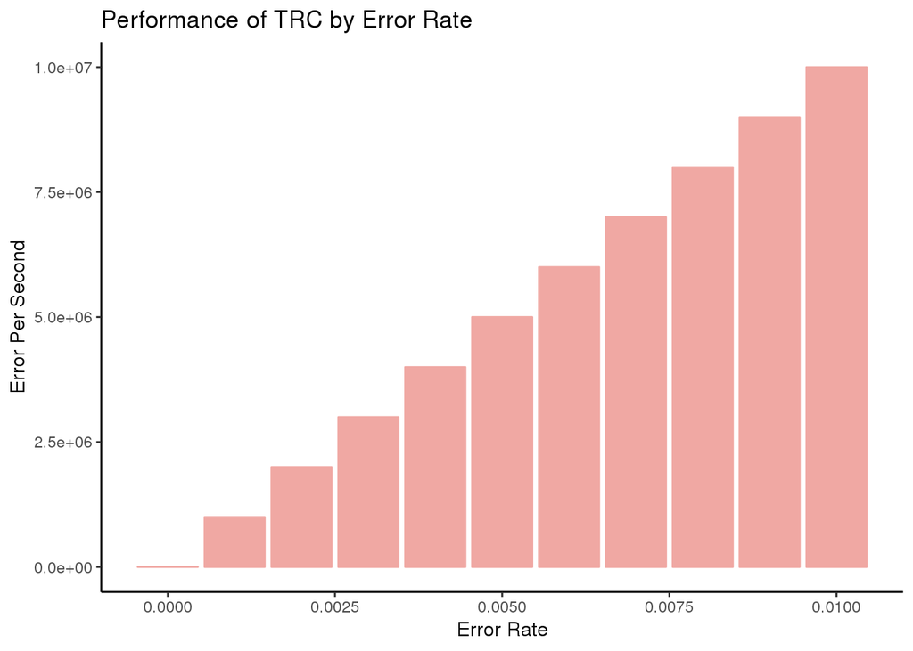

```r
a <- seq(0, .01, by = .001)
ErrorsPerSec <- 10^9 * a

ggplot(NULL, aes(x = a, y = ErrorsPerSec)) +
  geom_bar(stat = "identity", color = "#F0A8A3", fill = "#F0A8A3") +
  theme_classic() +
  labs(title = "Performance of TRC by Error Rate", x = "Error Rate", y = "Error Per Second")
```

```r
10^9 * .0001
```

```
[1] 1e+05
```

```r
print("The inital error needs to be reduced to .0001")
```

```
[1] "The inital error needs to be reduced to .0001"
```

ANSWER:

2. A 1000 Mbit/s system transmits 10<sup>9</sup> bits per second. Each bit has a 0.03% chance of being incorrectly received when we use TRC and all bits are independent. There are are 86,400 seconds in a day. If X is the number of incorrect bits in a single second, use `rbinom` to simulate the distribution of X for a single day. Assess your simulation results for normality using a density plot, ECDF plot, QQ plot, and goodness of fit test. What do you conclude?

Simulation:

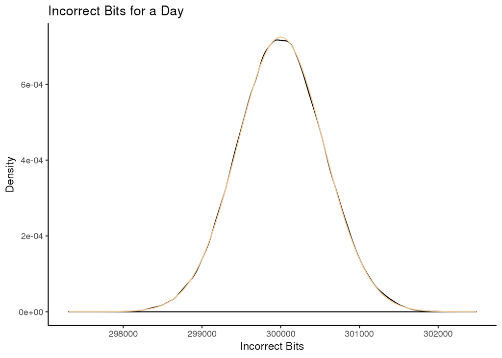

```r
prob <- rbinom(86400,10^9,.0003) %>%
  as.data.frame()

M <- mean(prob$.)
S <- sd(prob$.)

prob <- prob %>% mutate(normtestcats = case_when(. <= M - 2*S ~ "C1",
                                                 . <= M - 1*S & . > M - 2*S ~ "C2",
                                                 . <= M - 0*S & . > M - 1*S ~ "C3",
                                                 . <= M + 1*S & . > M - 0*S ~ "C4",
                                                 . <= M + 2*S & . > M + 1*S ~ "C5",
                                                 . >  M + 2*S ~ "C6"))
x <- prob$.
x.q <- quantile(prob$.)

ggplot(prob, aes(x = .)) +
  geom_density() +
  stat_function(fun = dnorm, args = list(M, S), color = "#F5CB9B") +
  theme_classic() +
  labs(title = "Incorrect Bits for a Day", y = "Density", x = "Incorrect Bits")
```

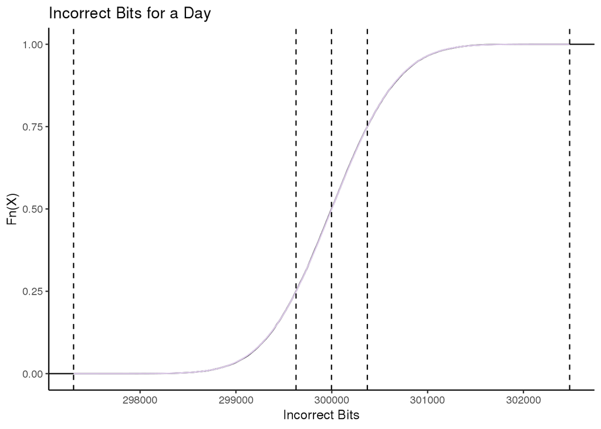

```r
ggplot(NULL, aes(x = x)) +
  geom_step(stat = "ecdf") +
  stat_function(fun = pnorm, args = list(M, S), color = "#E0CDED") +
  theme_classic() +
  labs(title = "Incorrect Bits for a Day", y = "Fn(X)", x = "Incorrect Bits") +
  geom_vline(aes(xintercept=x.q),linetype = "dashed")
```

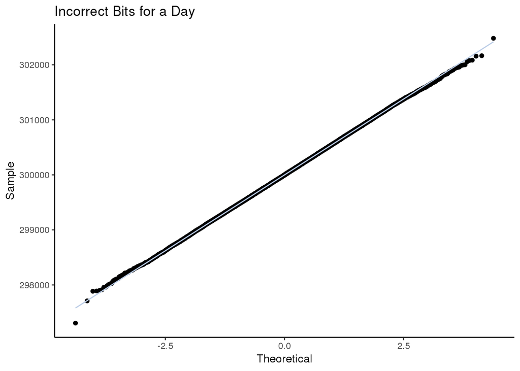

```r
ggplot(prob, aes(sample = .)) +
  stat_qq() +
  stat_qq_line(color = "#BACCE6") +
  theme_classic() +
  labs(title = "Incorrect Bits for a Day", x = "Theoretical", y = "Sample")
```

Ho: X is normal distributed.

Ha: X is not normal distributed.

Goodness of Fit Test:

```r
observed <- table(prob$normtestcats)

probs <- c(pnorm(-2),
           pnorm(-1) - pnorm(-2),
           pnorm(0) - pnorm(-1),
           pnorm(1) - pnorm(0),
           pnorm(2) - pnorm(1),
           pnorm(2, lower.tail=F))

expected <- probs * sum(observed)

testStat <- sum((observed - expected)^2 / expected)
DF <- length(observed) - 3
pvalue <- pchisq(testStat, DF, lower.tail = FALSE)

print(testStat)
```

```
[1] 3.363703
```

```r
print(pvalue)
```

```
[1] 0.3388744
```

Conclusions: From the graphs X looks to be a strong normal distribution, and our p-value indicates that with a value greater than .1.

END PART 2